# Inference for One Mean

Elementary Statistics

MTH-161D | Spring 2025 | University of Portland

March 31, 2025

# Objectives

- **Develop an understanding of t-distributions**
- **Know how to compute confidence intervals for one mean**
- **Understand the conditions for the Central Limit Theorem (CLT) for sample means.**
- **Activity: Determine Confidence Intervals for One Mean**

*These slides are derived from Diez et al. (2012).*

# Previously…

**Central Limit Theorem (CLT)**

CLT says that the sample mean (or sum) of many independent and identically distributed random variables approaches a normal distribution, regardless of the original distribution.

**CLT Conditions**

- **Independence** – Sample values must be independent
- **Identical Distribution** – Variables should be from the same distribution
- **Finite Variance** – The population must have a finite variance
- **Large Sample Size** – A larger sample size improves approximation

# Central Limit Theorem for the Sample Mean

When we collect a sufficiently large sample of $n$ independent observations from a population with mean $\mu$ and standard deviation $\sigma,$ the sampling distribution of $\bar{x}$ will be nearly normal with
$$\text{Mean}
\longrightarrow \mu \text{ and } \text{Standard Error} \longrightarrow
SE = \frac{\sigma}{\sqrt{n}}.$$

# Evaluating the two conditions required for modeling $\bar{x}$

Two conditions are required to apply the Central Limit Theorem for a sample mean $\bar{x}:$

- **Independence.** The sample observations must be independent. The most common way to satisfy this condition is when the sample is a simple random sample from the population.
- **Normality.** When a sample is small, we also require that the sample observations come from a normally distributed population. We can relax this condition more and more for larger and larger sample sizes. *This condition is obviously vague, making it difficult to evaluate, so next we introduce a couple rules of thumb to make checking this condition easier.*

# General rule for performing the normality check

Note, it often takes practice to get a sense for whether or not a normal approximation is appropriate.

- $\mathbf{n < 30}:$ If the sample size $n$ is less than 30 and there are **no clear outliers** in the data, then we typically assume the data come from a nearly normal distribution to satisfy the condition.
- $\mathbf{n \geq 30}:$ If the sample size $n$ is at least 30 and there are no **particularly extreme** outliers, then we typically assume the sampling distribution of $\bar{x}$ is nearly normal, even if the underlying distribution of individual observations is not.

# Normality Assesment (1/2)

Consider the four plots provided that come from simple random samples from different populations.

*Are the independence and normality conditions met in each case?*

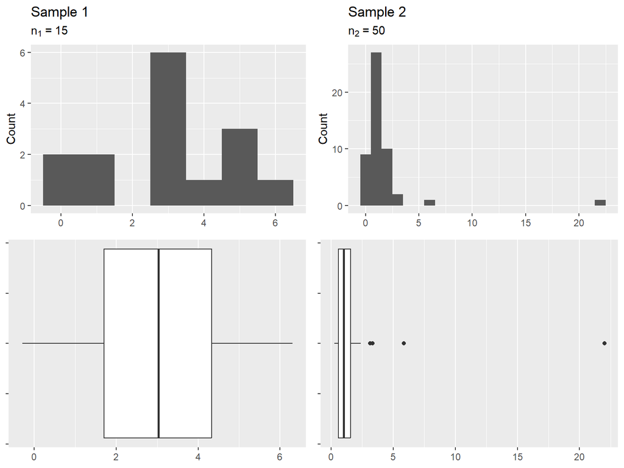

Histograms of samples from two different populations.

# Normality Assesment (2/2)

- The **first sample** has fewer than 30 observations, so we are watching for any clear outliers. *With no clear outliers, the normality condition can be reasonably assumed to be met.*
- The **second sample** has a sample size greater than 30 and includes an outlier. *This is an example of a particularly extreme outlier, so the normality condition would not be satisfied.*

# The t-distribution (1/2)

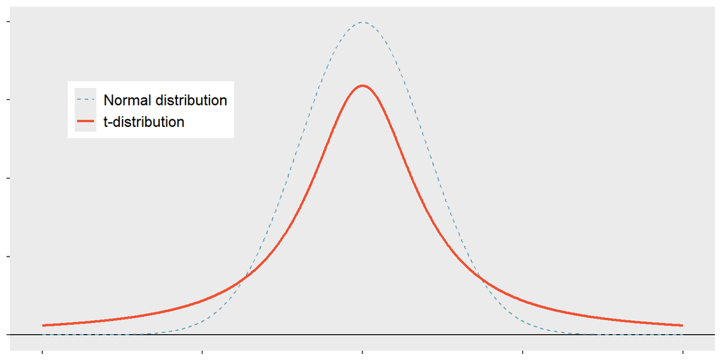

Comparison of a $t$-distribution and a normal distribution.

The $t$-distribution is always centered at zero and has a single parameter: degrees of freedom. The **degrees of freedom** describes the precise form of the bell-shaped $t$-distribution. In general, we’ll use a $t$-distribution with $df = n - 1$ to model the sample mean when the sample size is $n$.

# The t-distribution (2/2)

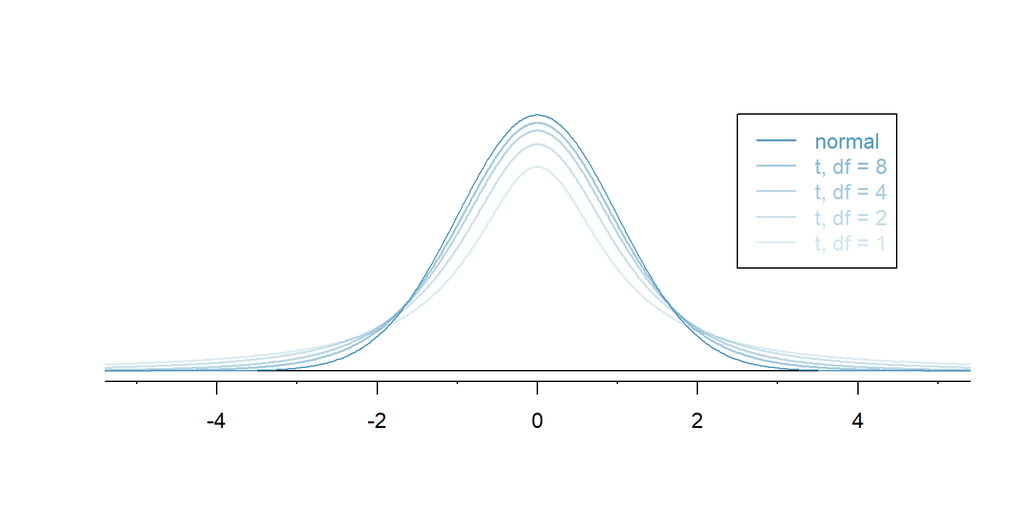

The larger the degrees of freedom the more closely the $t$-distribution resembles the standard normal distribution.

# Case Study I: Mercury content in Risso’s dolphins

We will identify a confidence interval for the average mercury content in dolphin muscle using a sample of 19 Risso’s dolphins from the Taiji area in Japan.

Summary of mercury content in the muscle of 19 Risso’s dolphins from the Taiji area. Measurements are in micrograms of mercury per wet gram of muscle $(\mu$g/wet g).

| n | Mean | SD | Min | Max |
| --- | --- | --- | --- | --- |
| 19 | 4.4 | 2.3 | 1.7 | 9.2 |

**Are the independence and normality conditions satisfied for this dataset?**

- The observations are a simple random sample, therefore it is reasonable to assume that the dolphins are independent.
- The summary statistics do not suggest any clear outliers, with all observations within 3 standard deviations of the mean.
- Based on this evidence, the normality condition seems reasonable.

# Case Study I: One-sample t-interval (1/2)

**One sample t-intervals**

$$\begin{aligned}
\text{point estimate} \ &\pm\ t^*_{df} \times SE \\
\bar{x} \ &\pm\ t^*_{df} \times \frac{s}{\sqrt{n}}
\end{aligned}$$

- We plug in $s$ and $n$ into the formula: $SE = \frac{s}{\sqrt{n}} = \frac{2.3}{\sqrt{19}} = 0.528.$
- The degrees of freedom is easy to calculate: $df = n-1 = 19-1 = 18.$
- We find the cutoff where the upper tail is equal to 2.5%: $t^*_{18} = 2.10.$ The area below -2.10 will also be equal to 2.5%.

**Using R to find $t^*$**

```r
qt(0.025, df = 18)
```

```
## [1] -2.100922
```

# Case Study I: One-sample t-interval (2/2)

**One sample t-intervals**

$$\begin{aligned}
\bar{x} \ &\pm\ t^*_{18} \times SE \\
4.4 \ &\pm\ 2.10 \times 0.528 \\
\end{aligned}$$
$$(3.29,5.51)$$

We are 95% confident the average mercury content of muscles in Risso’s dolphins is between 3.29 and 5.51 $\mu$g/wet gram, which is considered extremely high.

# Activity: Determine Confidence Intervals for One Mean

1. Make sure you have a copy of the *M 3/31 Worksheet*. This will be handed out physically. This worksheet will be available on Moodle after class.
2. Work on your worksheet by yourself for 10 minutes. Please read the instructions carefully. Ask questions if anything need clarifications.
3. Get together with another student.
4. Discuss your results.
5. Submit your worksheet on Moodle as a `.pdf` file.

# References

Diez, D. M., Barr, C. D., & Çetinkaya-Rundel, M. (2012). *OpenIntro statistics* (4th ed.). OpenIntro. https://www.openintro.org/book/os/